# PA1_template

BigAl37

29 February 2016

## Loading Packages

```r
library(ggplot2)
library(plyr)
```

## Loading and preprocessing the data

### Download Data

```r
if(!file.exists("repdata-data-activData.zip")) {
  zipTemp <- tempfile()
  download.file("https://d396qusza40orc.cloudfront.net/repdata%2Fdata%2Factivity.zip",zipTemp)
  workFile <- unzip(zipTemp)
  unlink(zipTemp)
} else {
  workFile <- unzip("repdata-data-activData.zip")
}
```

## Load the data (i.e. read.csv())

```r
activData <- read.table(workFile, header = T, sep = ",")
```

## Process/transform the data (if necessary) into a format suitable for your analysis

### Convert to date

```r
activData$date <- as.Date(activData$date,  "%Y-%m-%d")
```

# What is mean total number of steps taken per day?

## Calculate the total number of steps taken per day

```r
byDay <- aggregate(steps ~ date, data = activData, sum)
```

## If you do not understand the difference between a histogram and a barplot, research the difference between them. Make a histogram of the total number of steps taken each day

### Histogram

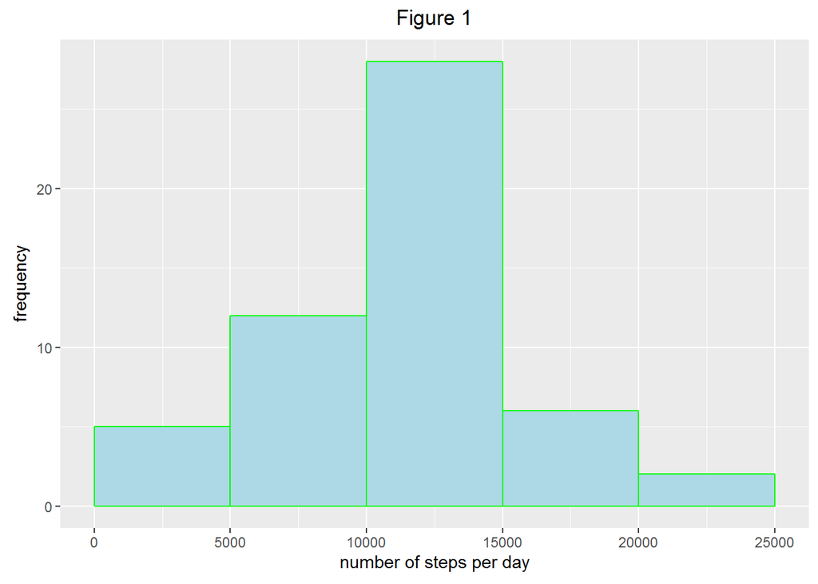

```r
library(ggplot2)
ggplot(byDay, aes(steps)) + geom_histogram(fill = "lightblue", colour = "green",
                                           breaks = c(0, 5000, 10000, 15000, 20000, 25000)) + labs(y = expression("frequency")) +
  labs(x = expression("number of steps per day")) + labs(title = expression("Figure 1"))
```

## Calculate and report the mean and median of the total number of steps taken per day

### Mean and Median

```r
mean1 <- mean(byDay$steps)
mean1
```

```
## [1] 10766.19
```

```r
median1 <- median(byDay$steps)
median1
```

```
## [1] 10765
```

# What is the average daily activity pattern?

## Make a time series plot (i.e. type = “l”) of the 5-minute interval (x-axis) and the average number of steps taken, averaged across all days (y-axis)

### Time series plot

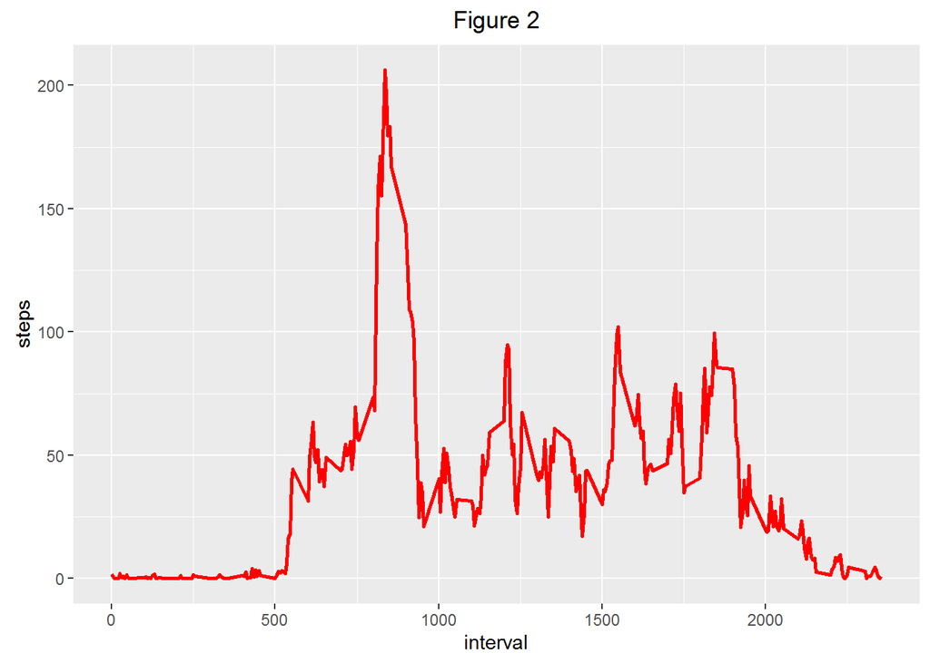

```r
byInterval<- aggregate(steps ~ interval, data = activData, FUN = function(x) {
  mean(x, na.rm = TRUE)
})
ggplot(byInterval, aes(interval, steps)) + geom_line(colour = "red",
                                                      lwd = 1) + labs(title = expression("Figure 2"))
```

## Which 5-minute interval, on average across all the days in the dataset, contains the maximum number of steps?

### Maximum interval

```r
byInterval$interval[which.max(byInterval$steps)]
```

```
## [1] 835
```

## Maximum value

```r
max(byInterval$steps)
```

```
## [1] 206.1698
```

# Imputing missing values

## Calculate and report the total number of missing values in the dataset (i.e. the total number of rows with NAs)

```r
na <- sum(is.na(activData))
c("The total number of NAs is: ", na)
```

```
## [1] "The total number of NAs is: " "2304"
```

## Devise a strategy for filling in all of the missing values in the dataset. The strategy does not need to be sophisticated. For example, you could use the mean/median for that day, or the mean for that 5-minute interval, etc.

```r
activDataNew <- activData
for (i in 1:length(activData$steps)) {
  if (is.na(activData[i, 1])) {


    stepsAverage <- subset(byInterval, byInterval$interval == as.numeric(activData[i, 3]))$steps

    activDataNew[i, 1] <- stepsAverage
  } else {
    activDataNew[i, 1] <- activData[i, 1]
  }
  activData
}
```

## Create a new dataset that is equal to the original dataset but with the missing data filled in.

```r
head(activDataNew)
```

```
##       steps       date interval
## 1 1.7169811 2012-10-01        0
## 2 0.3396226 2012-10-01        5
## 3 0.1320755 2012-10-01       10
## 4 0.1509434 2012-10-01       15
## 5 0.0754717 2012-10-01       20
## 6 2.0943396 2012-10-01       25
```

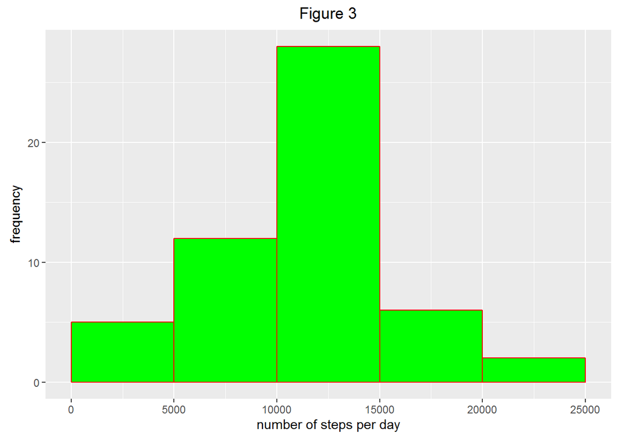

```r
library(ggplot2)
ggplot(byDay, aes(steps)) + geom_histogram(fill = "green", colour = "red",
                                             breaks = c(0, 5000, 10000, 15000, 20000, 25000)) + labs(y = expression("frequency")) +
  labs(x = expression("number of steps per day")) + labs(title = expression("Figure 3"))
```

# Are there differences in activity patterns between weekdays and weekends?

## Create a new factor variable in the dataset with two levels - “weekday” and “weekend” indicating whether a given date is a weekday or weekend day.

### Add a column for weekdays

```r
activDataNew <- mutate(activDataNew, day = weekdays(date))
```

### Weekend Variable

```r
weekendVar <- c("Saturday", "Sunday")
```

### Creates a factor variable with 2 levels

```r
for (i in 1:length(activDataNew$day)) {
  if (activDataNew[i, 4] == weekendVar[1] || activDataNew[i, 4] == weekendVar[2] ) {
    activDataNew[i, 4] <- "weekend"

  } else {
    activDataNew[i, 4] <- "weekday"

  }
}
activDataNew$day <- as.factor(activDataNew$day)
```

## Make a panel plot containing a time series plot (i.e. type = “l”) of the 5-minute interval (x-axis) and the average number of steps taken, averaged across all weekday days or weekend days (y-axis). See the README file in the GitHub repository to see an example of what this plot should look like using simulated data.

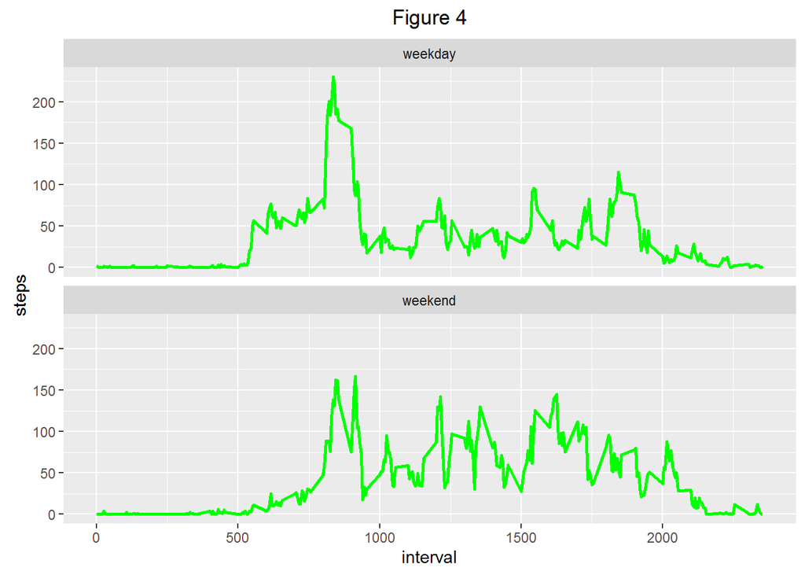

```r
summary <- aggregate(activDataNew$steps, list(interval = activDataNew$interval, day = activDataNew$day),
                     mean)
names(summary) <- c("interval", "day", "steps")

## Plot using ggplot2
library(ggplot2)
ggplot(summary, aes(interval, steps)) + geom_line(color = "green", lwd = 1) +
  facet_wrap(~day, ncol = 1) + labs(title = expression("Figure 4"))
```